# Global Child Health Indicators

Azaruddin Manchenahalli Nissar

ID: A00048454

# Importing Libraries & Loading Data

```python
#!pip install pycountry
```

```python
import pandas as pd
import geopandas as gpd
from plotnine import *
import pycountry

# Load datasets
indicator_df = pd.read_csv('Azar_indicator_1.csv')
metadata_df = pd.read_csv('Azar_metadata.csv')
```

```python
# Display sample data
indicator_df.head()
```

|  | country | alpha_2_code | alpha_3_code | numeric_code | indicator | time_period | obs_value | sex | unit_multiplier | unit_of_measure | observation_status | observation_confidentaility | time_period_activity_related_to_when_the_data_are_collected | current_age |
| --- | --- | --- | --- | --- | --- | --- | --- | --- | --- | --- | --- | --- | --- | --- |
| 0 | Afghanistan | AF | AFG | 4 | Postnatal care for newborns - percentage of ne... | 2015 | 9.3 | Total | Units | % | Reported | Free | End of fieldwork | Total |
| 1 | Afghanistan | AF | AFG | 4 | Postnatal care for newborns - percentage of ne... | 2018 | 19.3 | Total | Units | % | Reported | Free | End of fieldwork | Total |
| 2 | Afghanistan | AF | AFG | 4 | Postnatal care for newborns - percentage of ne... | 2023 | 34.2 | Total | Units | % | Reported | Free | End of fieldwork | Total |
| 3 | Albania | AL | ALB | 8 | Postnatal care for newborns - percentage of ne... | 2018 | 86.2 | Total | Units | % | Reported | Free | End of fieldwork | Total |
| 4 | Algeria | DZ | DZA | 12 | Postnatal care for newborns - percentage of ne... | 2019 | 91.5 | Total | Units | % | Reported | Free | End of fieldwork | Total |

```python
indicator_df.info()
```

```
<class 'pandas.core.frame.DataFrame'>
RangeIndex: 212 entries, 0 to 211
Data columns (total 14 columns):
 #   Column                                                       Non-Null Count  Dtype
---  ------                                                       --------------  -----
 0   country                                                      212 non-null    object
 1   alpha_2_code                                                 211 non-null    object
 2   alpha_3_code                                                 212 non-null    object
 3   numeric_code                                                 212 non-null    int64
 4   indicator                                                    212 non-null    object
 5   time_period                                                  212 non-null    int64
 6   obs_value                                                    212 non-null    float64
 7   sex                                                          212 non-null    object
 8   unit_multiplier                                              212 non-null    object
 9   unit_of_measure                                              212 non-null    object
 10  observation_status                                           212 non-null    object
 11  observation_confidentaility                                  212 non-null    object
 12  time_period_activity_related_to_when_the_data_are_collected  212 non-null    object
 13  current_age                                                  212 non-null    object
dtypes: float64(1), int64(2), object(11)
memory usage: 23.3+ KB
```

```python
# Display sample data
metadata_df.head()
```

|  | country | alpha_2_code | alpha_3_code | numeric_code | year | Population, total | GDP per capita (constant 2015 US$) | GNI (current US$) | Inflation, consumer prices (annual %) | Life expectancy at birth, total (years) | Military expenditure (% of GDP) | Fossil fuel energy consumption (% of total) | GDP growth (annual %) | Birth rate, crude (per 1,000 people) | Hospital beds (per 1,000 people) |
| --- | --- | --- | --- | --- | --- | --- | --- | --- | --- | --- | --- | --- | --- | --- | --- |
| 0 | Afghanistan | AF | AFG | 4 | 1960 | 9035043.0 | NaN | 5.488888e+08 | NaN | 32.535 | NaN | NaN | NaN | 50.340 | 0.170627 |
| 1 | Afghanistan | AF | AFG | 4 | 1961 | 9214083.0 | NaN | 5.600000e+08 | NaN | 33.068 | NaN | NaN | NaN | 50.443 | NaN |
| 2 | Afghanistan | AF | AFG | 4 | 1962 | 9404406.0 | NaN | 5.577778e+08 | NaN | 33.547 | NaN | NaN | NaN | 50.570 | NaN |
| 3 | Afghanistan | AF | AFG | 4 | 1963 | 9604487.0 | NaN | 7.666667e+08 | NaN | 34.016 | NaN | NaN | NaN | 50.703 | NaN |
| 4 | Afghanistan | AF | AFG | 4 | 1964 | 9814318.0 | NaN | 8.155556e+08 | NaN | 34.494 | NaN | NaN | NaN | 50.831 | NaN |

```python
metadata_df.info()
```

```
<class 'pandas.core.frame.DataFrame'>
RangeIndex: 13504 entries, 0 to 13503
Data columns (total 15 columns):
 #   Column                                       Non-Null Count  Dtype
---  ------                                       --------------  -----
 0   country                                      13504 non-null  object
 1   alpha_2_code                                 13504 non-null  object
 2   alpha_3_code                                 13504 non-null  object
 3   numeric_code                                 13504 non-null  int64
 4   year                                         13504 non-null  int64
 5   Population, total                            13474 non-null  float64
 6   GDP per capita (constant 2015 US$)           10962 non-null  float64
 7   GNI (current US$)                            10691 non-null  float64
 8   Inflation, consumer prices (annual %)        8689 non-null   float64
 9   Life expectancy at birth, total (years)      12728 non-null  float64
 10  Military expenditure (% of GDP)              7699 non-null   float64
 11  Fossil fuel energy consumption (% of total)  5818 non-null   float64
 12  GDP growth (annual %)                        10883 non-null  float64
 13  Birth rate, crude (per 1,000 people)         12898 non-null  float64
 14  Hospital beds (per 1,000 people)             4717 non-null   float64
dtypes: float64(10), int64(2), object(3)
memory usage: 1.5+ MB
```

# Data Cleaning & Preparation

```python
# Focus on a specific indicator (example)
selected_indicator = indicator_df['indicator'].unique()[0]

# Filter indicator data for that indicator
filtered_indicator = indicator_df[indicator_df['indicator'] == selected_indicator]

# Merge with metadata on 'country' and 'year' (time_period)
merged_df = pd.merge(filtered_indicator, metadata_df,
                     left_on=['country', 'time_period'],
                     right_on=['country', 'year'],
                     how='left')

# Drop rows where GDP per capita is missing (for scatterplot)
merged_df = merged_df.dropna(subset=['GDP per capita (constant 2015 US$)'])
```

```python
merged_df.head()
```

|  | country | alpha_2_code_x | alpha_3_code_x | numeric_code_x | indicator | time_period | obs_value | sex | unit_multiplier | unit_of_measure | ... | Population, total | GDP per capita (constant 2015 US$) | GNI (current US$) | Inflation, consumer prices (annual %) | Life expectancy at birth, total (years) | Military expenditure (% of GDP) | Fossil fuel energy consumption (% of total) | GDP growth (annual %) | Birth rate, crude (per 1,000 people) | Hospital beds (per 1,000 people) |
| --- | --- | --- | --- | --- | --- | --- | --- | --- | --- | --- | --- | --- | --- | --- | --- | --- | --- | --- | --- | --- | --- |
| 0 | Afghanistan | AF | AFG | 4 | Postnatal care for newborns - percentage of ne... | 2015 | 9.3 | Total | Units | % | ... | 33831764.0 | 565.569730 | 1.924950e+10 | -0.661709 | 62.659 | 0.994576 | NaN | 1.451315 | 38.803 | 0.44 |
| 1 | Afghanistan | AF | AFG | 4 | Postnatal care for newborns - percentage of ne... | 2018 | 19.3 | Total | Units | % | ... | 36743039.0 | 553.125152 | 1.829451e+10 | 0.626149 | 63.081 | 1.006746 | NaN | 1.189228 | 36.927 | 0.40 |
| 2 | Afghanistan | AF | AFG | 4 | Postnatal care for newborns - percentage of ne... | 2023 | 34.2 | Total | Units | % | ... | 41454761.0 | 379.707497 | 1.731538e+10 | NaN | NaN | NaN | NaN | 2.710887 | NaN | NaN |
| 3 | Albania | AL | ALB | 8 | Postnatal care for newborns - percentage of ne... | 2018 | 86.2 | Total | Units | % | ... | 2866376.0 | 4431.555595 | 1.536107e+10 | 2.028060 | 79.184 | 1.160545 | NaN | 4.019346 | 10.517 | 2.84 |
| 4 | Algeria | DZ | DZA | 12 | Postnatal care for newborns - percentage of ne... | 2019 | 91.5 | Total | Units | % | ... | 43294546.0 | 4672.664087 | 1.895486e+11 | 1.951768 | 76.474 | 5.999941 | NaN | 0.900000 | 23.298 | NaN |

5 rows × 28 columns

```python
merged_df.info()
```

```
<class 'pandas.core.frame.DataFrame'>
Index: 209 entries, 0 to 211
Data columns (total 28 columns):
 #   Column                                                       Non-Null Count  Dtype
---  ------                                                       --------------  -----
 0   country                                                      209 non-null    object
 1   alpha_2_code_x                                               209 non-null    object
 2   alpha_3_code_x                                               209 non-null    object
 3   numeric_code_x                                               209 non-null    int64
 4   indicator                                                    209 non-null    object
 5   time_period                                                  209 non-null    int64
 6   obs_value                                                    209 non-null    float64
 7   sex                                                          209 non-null    object
 8   unit_multiplier                                              209 non-null    object
 9   unit_of_measure                                              209 non-null    object
```

[output cut: 20 more lines]

```python
# Check number of nulls in each column
merged_df.isna().sum()
```

```
country                                                          0
alpha_2_code_x                                                   0
alpha_3_code_x                                                   0
numeric_code_x                                                   0
indicator                                                        0
time_period                                                      0
obs_value                                                        0
sex                                                              0
unit_multiplier                                                  0
unit_of_measure                                                  0
observation_status                                               0
observation_confidentaility                                      0
time_period_activity_related_to_when_the_data_are_collected      0
current_age                                                      0
alpha_2_code_y                                                   0
alpha_3_code_y                                                   0
numeric_code_y                                                   0
year                                                             0
Population, total                                                0
GDP per capita (constant 2015 US$)                               0
GNI (current US$)                                                1
Inflation, consumer prices (annual %)                           14
Life expectancy at birth, total (years)                          3
Military expenditure (% of GDP)                                 33
Fossil fuel energy consumption (% of total)                    152
GDP growth (annual %)                                            1
Birth rate, crude (per 1,000 people)                             3
Hospital beds (per 1,000 people)                                98
dtype: int64
```

```python
# Define critical columns for analysis
critical_columns = ['obs_value', 'GDP per capita (constant 2015 US$)',
                    'Life expectancy at birth, total (years)',
                    'Birth rate, crude (per 1,000 people)']

# Drop rows where obs_value is missing
cleaned_df = merged_df.dropna(subset=['obs_value'])

# For specific analysis, drop rows missing the relevant variable
# Example: For GDP analysis
gdp_analysis_df = cleaned_df.dropna(subset=['GDP per capita (constant 2015 US$)'])

# Example: For Life Expectancy analysis
life_exp_analysis_df = cleaned_df.dropna(subset=['Life expectancy at birth, total (years)'])

# Optionally, fill less critical numeric columns with median
cleaned_df.fillna({
    'Hospital beds (per 1,000 people)': cleaned_df['Hospital beds (per 1,000 people)'].median(),
    'GDP growth (annual %)': cleaned_df['GDP growth (annual %)'].median()
}, inplace=True)
```

```python
print(f"Shape after cleaning: {cleaned_df.shape}")
print(cleaned_df.isna().sum())
```

```
Shape after cleaning: (209, 28)
country                                                          0
alpha_2_code_x                                                   0
alpha_3_code_x                                                   0
numeric_code_x                                                   0
indicator                                                        0
time_period                                                      0
obs_value                                                        0
sex                                                              0
unit_multiplier                                                  0
unit_of_measure                                                  0
observation_status                                               0
observation_confidentaility                                      0
time_period_activity_related_to_when_the_data_are_collected      0
current_age                                                      0
alpha_2_code_y                                                   0
alpha_3_code_y                                                   0
numeric_code_y                                                   0
year                                                             0
Population, total                                                0
GDP per capita (constant 2015 US$)                               0
GNI (current US$)                                                1
Inflation, consumer prices (annual %)                           14
Life expectancy at birth, total (years)                          3
Military expenditure (% of GDP)                                 33
Fossil fuel energy consumption (% of total)                    152
GDP growth (annual %)                                            0
Birth rate, crude (per 1,000 people)                             3
Hospital beds (per 1,000 people)                                 0
dtype: int64
```

# World Map Chart

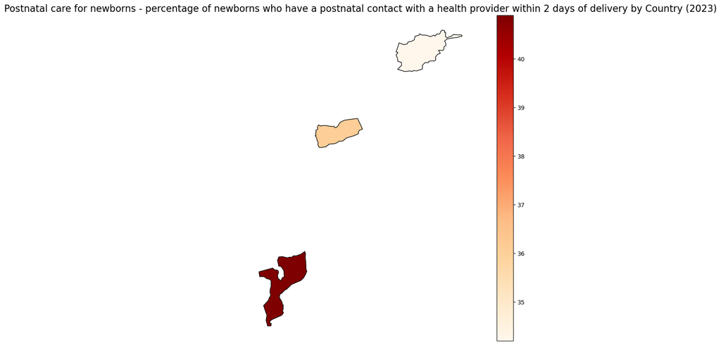

```python
# Import required libraries
import pandas as pd
import geopandas as gpd
import matplotlib.pyplot as plt

#  Load indicator and metadata CSV files
indicator_df = pd.read_csv('Azar_indicator_1.csv')
metadata_df = pd.read_csv('Azar_metadata.csv')

# Get the latest year from indicator_df
latest_year = indicator_df['time_period'].max()

# Filter data for that year only
map_data = indicator_df[indicator_df['time_period'] == latest_year]

# Corrected Merge: Match 'time_period' with 'year'
map_data = pd.merge(
    map_data,
    metadata_df,
    left_on=['country', 'time_period'],
    right_on=['country', 'year'],
    how='left'
)

# Rename alpha_3_code_x to a usable name
map_data = map_data.rename(columns={'alpha_3_code_x': 'alpha_3_code'})

# Load the Natural Earth shapefile (.shp)
world = gpd.read_file('shapefiles/ne_110m_admin_0_countries.shp')

# Merge the GeoDataFrame with your map data using alpha-3 codes
world_data = world.merge(map_data, left_on='SOV_A3', right_on='alpha_3_code')

# Plot the World Map using GeoPandas' native plot
fig, ax = plt.subplots(figsize=(15, 10))

world_data.plot(
    column='obs_value',
    ax=ax,
    legend=True,
    cmap='OrRd',
    edgecolor='black'
)

# Add titles and remove axes
indicator_title = map_data['indicator'].iloc[0]
ax.set_title(f"{indicator_title} by Country ({latest_year})", fontsize=16)
ax.set_axis_off()

# Show the map
plt.show()
```

The figure shows disparities in postnatal care coverage by country. The data is reported only by a few nations, Mozambique, Yemen, and Afghanistan, with reporting limited to the world or low healthcare outreach. The darker shades represent the percentages of newborns that receive postnatal care within two days of being delivered. The visual portrays the importance of grounding these areas in efforts to provide better services within these underprivileged regions and invigorate data collection mechanisms that are insufficient in the global healthcare sector.

# Bar Chart – Top 10 Countries by Indicator Value

[figure not shown]

```python
from plotnine import *

# Sort and get top 10 countries by obs_value
top10 = map_data.sort_values(by='obs_value', ascending=False).head(10)

# Create larger bar plot
(
    ggplot(top10, aes(x='reorder(country, obs_value)', y='obs_value')) +
    geom_bar(stat='identity', fill='skyblue') +
    coord_flip() +
    labs(
        title=f'Top 10 Countries by {top10["indicator"].iloc[0]} ({latest_year})',
        x='Country',
        y='Postnatal Care Coverage (%)'
    ) +
    theme_minimal() +
    theme(
        figure_size=(12, 8),  # Increased width and height
        axis_title=element_text(size=12),
        axis_text=element_text(size=11),
        plot_title=element_text(size=14, weight='bold')
    )
)
```

The above bar chart shows the top countries with the maximum postnatal care coverage in 2023. The percentage is highest in Mozambique, then Yemen, and Afghanistan. This visualization effectively shows in a way that some of the underdeveloped countries, even with their economic challenges, are doing their best to improve newborn healthcare. However, data scarcity is indicated by the few number of countries, which are reported. This calls for wider involvement of reporters, and as such, needs to be used to monitor progress and manage gaps in global health reporting.

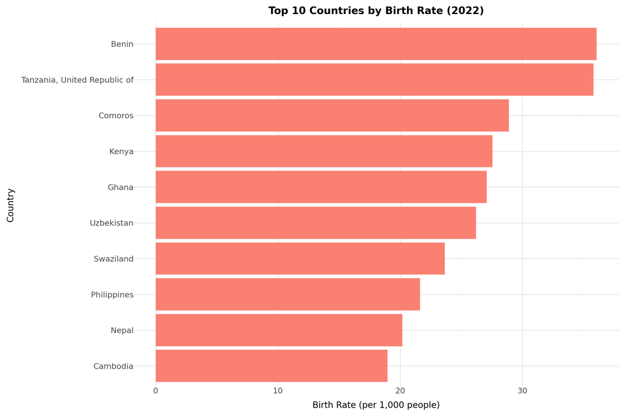

```python
from plotnine import *

# Rename the birth rate column for easier plotting
birth_rate_data = cleaned_df.rename(columns={
    'Birth rate, crude (per 1,000 people)': 'birth_rate'
})

# Drop missing values
birth_rate_data = birth_rate_data.dropna(subset=['birth_rate'])

# Use latest year data
latest_year_birth = birth_rate_data['time_period'].max()
birth_rate_latest = birth_rate_data[birth_rate_data['time_period'] == latest_year_birth]

# Get Top 10 countries by birth rate
top10_birth_rate = birth_rate_latest.sort_values(by='birth_rate', ascending=False).head(10)

# Plot Bar Chart
(
    ggplot(top10_birth_rate, aes(x='reorder(country, birth_rate)', y='birth_rate')) +
    geom_bar(stat='identity', fill='salmon') +
    coord_flip() +
    labs(
        title=f'Top 10 Countries by Birth Rate ({latest_year_birth})',
        x='Country',
        y='Birth Rate (per 1,000 people)'
    ) +
    theme_minimal() +
    theme(
        figure_size=(12, 8),
        axis_title=element_text(size=12),
        axis_text=element_text(size=11),
        plot_title=element_text(size=14, weight='bold')
    )
)
```

It can be seen in this chart that, in terms of birth rates, countries such as Benin and Tanzania are at the top. Generally, high birth rates correspond with high pressure on the healthcare systems, in particular on maternal and child healthcare systems. Demand for postnatal care in these countries tends to be inherently higher, and the visualization shows regions to strengthen healthcare infrastructure in these nations. In addition, it is a dominant indicator to policymakers for the task of aligning healthcare resources to demographic trends to improve child survival rates in high birth rate countries.

# Scatterplot – GDP vs Indicator Value with Regression Line

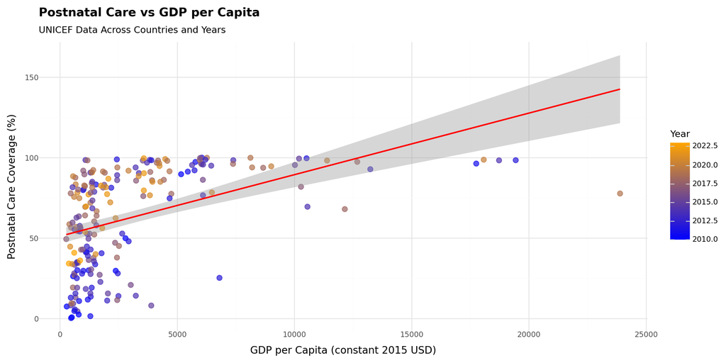

```python
from plotnine import *

# Rename for easier use
scatter_data = cleaned_df.rename(columns={
    'GDP per capita (constant 2015 US$)': 'gdp_per_capita'
})

# Scatterplot: Postnatal Care vs GDP per Capita
(
    ggplot(scatter_data, aes(x='gdp_per_capita', y='obs_value')) +
    geom_point(aes(color='time_period'), size=3, alpha=0.7) +
    geom_smooth(method='lm', color='red') +
    scale_color_gradient(low='blue', high='orange') +
    labs(
        title='Postnatal Care vs GDP per Capita',
        subtitle='UNICEF Data Across Countries and Years',
        x='GDP per Capita (constant 2015 USD)',
        y='Postnatal Care Coverage (%)',
        color='Year'
    ) +
    theme_minimal() +
    theme(
        figure_size=(12, 6),
        axis_title=element_text(size=12),
        plot_title=element_text(size=14, weight='bold'),
        plot_subtitle=element_text(size=11)
    )
)
```

In this scatterplot, there is a positive correlation between GDP per capita and Postnatal care coverage. However, the upward trend reflects that Wealthier countries give better access to children to use in the health care of newborns. However, there are several countries whose GDP is lower but whose postnatal care percentages are also very commendable, which suggests that policy focus can overcome economic limitations. The graph reinforces the economic strength is a role in healthcare outcomes, as well as suggests that targeted health interventions can also help improve child health even in low-income settings.

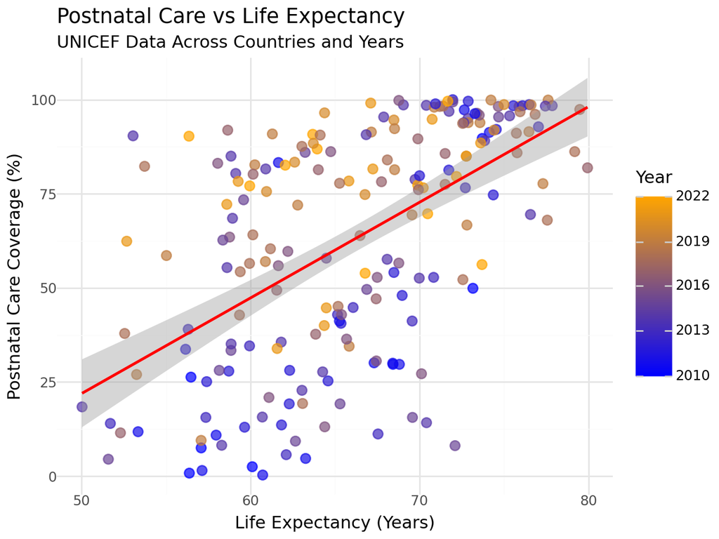

```python
# Rename for plotting
scatter_data = cleaned_df.rename(columns={
    'Life expectancy at birth, total (years)': 'life_expectancy'
})

# Drop 3 missing rows
scatter_data = scatter_data.dropna(subset=['life_expectancy'])

# Plot
(
    ggplot(scatter_data, aes(x='life_expectancy', y='obs_value')) +
    geom_point(aes(color='time_period'), size=3, alpha=0.7) +
    geom_smooth(method='lm', color='red') +
    scale_color_gradient(low='blue', high='orange') +
    labs(
        title='Postnatal Care vs Life Expectancy',
        subtitle='UNICEF Data Across Countries and Years',
        x='Life Expectancy (Years)',
        y='Postnatal Care Coverage (%)',
        color='Year'
    ) +
    theme_minimal()
)
```

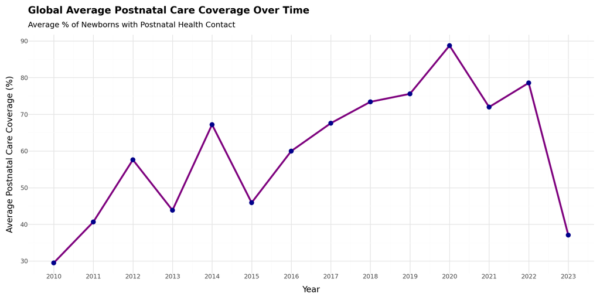

```python
from plotnine import *

# Group by year and calculate average postnatal care coverage
time_series_data = (
    cleaned_df.groupby('time_period')['obs_value']
    .mean()
    .reset_index()
)

# Plot the time-series chart
(
    ggplot(time_series_data, aes(x='time_period', y='obs_value')) +
    geom_line(color='purple', size=1.5) +
    geom_point(color='darkblue', size=3) +
    labs(
        title='Global Average Postnatal Care Coverage Over Time',
        subtitle='Average % of Newborns with Postnatal Health Contact',
        x='Year',
        y='Average Postnatal Care Coverage (%)'
    ) +
    scale_x_continuous(breaks=sorted(time_series_data['time_period'].unique())) +
    theme_minimal() +
    theme(
        figure_size=(12, 6),
        axis_title=element_text(size=12),
        plot_title=element_text(size=14, weight='bold'),
        plot_subtitle=element_text(size=11)
    )
)
```

# UNICEF Global Health Indicators Report

In this report, UNICEF’s key indicator data from various countries and years is visualized. We combine economic and health indicators to expose who is doing better and who is doing worse across the globe.